# Group Project #3

**Baseline + Uncertainty Results Discussion**

The code for testing our baseline case plus uncertainty (no rush hour scaling) is shown below along with the corresponding results. For this case, the model had quite a few routes that ended up being affected by the uncertainty (representing unexpected road work, accidents, etc.) - showing that our code to incorporate uncertainty is working. See routes 1 to 4, 1 to 8, 4 to 8, 8 to 6, 2 to 4, 2 to 3, and 3 to 5 (lots of accidents happened this day... could be the start of the apocolypse). All have been modified with a scaling factor between 10-15. This drastically changed the optimal route to take, changing from the base of 1, 4, 3 to 1,7,6,5,4,3 to avoid all the routes that had been affected. This is clearly due to accidents between nodes 1 and 4 as well as 1 and 8, making a roundabout path through node 7 a better option. Additional accidents between 3 and 5 and 4 and 8 also pushed the route down through 6 then back up through 4. This resulted in a total time of 27 minutes to get to the same location that took just 12 minutes in the base case. Again, we did manual calculations to verify this is the most efficient route to take given our graph.

```
The minimum travel time from (1)_Movement_Boulder to (3)_Chautauqua_Park is 27.0 minutes, following the route ['(1)', '(7)', '(6)', '(5)', '(4)', '(3)'].
```

|  | Current Node | t_min | Visited? | Optimal Path from (1) | Neighbor Node 01 | t_base_01 | t_mod_01 | Neighbor Node 02 | t_base_02 | t_mod_02 | Neighbor Node 03 | t_base_03 | t_mod_03 | Neighbor Node 04 | t_base_04 | t_mod_04 | Neighbor Node 05 | t_base_05 | t_mod_05 |
| --- | --- | --- | --- | --- | --- | --- | --- | --- | --- | --- | --- | --- | --- | --- | --- | --- | --- | --- | --- |
| 0 | (1)_Movement_Boulder | 0.0 | Yes | [None] | (4)_Pearl_Street_Mall | 7.0 | 91.0 | (8)_Whole_Foods_Market | 3 | 36 | (7)_Valmont_Dog_Park | 4 | 4 | - | - | - | - | - | - |
| 1 | (2)_Mount_Sanitas_Trailhead | 74.0 | Yes | [(1), (7), (6), (5), (4), (2)] | (3)_Chautauqua_Park | 7.0 | 105.0 | (4)_Pearl_Street_Mall | 4 | 52 | - | - | - | - | - | - | - | - | - |
| 2 | (3)_Chautauqua_Park | 27.0 | Yes | [(1), (7), (6), (5), (4), (3)] | (2)_Mount_Sanitas_Trailhead | 7.0 | 105.0 | (4)_Pearl_Street_Mall | 5 | 5 | (5)_Fiske_Planetarium | 4 | 56 | - | - | - | - | - | - |
| 3 | (4)_Pearl_Street_Mall | 22.0 | Yes | [(1), (7), (6), (5), (4)] | (1)_Movement_Boulder | 7.0 | 91.0 | (2)_Mount_Sanitas_Trailhead | 4 | 52 | (3)_Chautauqua_Park | 5 | 5 | (5)_Fiske_Planetarium | 5 | 5 | (8)_Whole_Foods_Market | 5 | 60 |
| 4 | (5)_Fiske_Planetarium | 17.0 | Yes | [(1), (7), (6), (5)] | (3)_Chautauqua_Park | 4.0 | 56.0 | (4)_Pearl_Street_Mall | 5 | 5 | (6)_Peleton_West | 7.5 | 7.5 | - | - | - | - | - | - |
| 5 | (6)_Peleton_West | 9.5 | Yes | [(1), (7), (6)] | (5)_Fiske_Planetarium | 7.5 | 7.5 | (8)_Whole_Foods_Market | 5 | 75 | (7)_Valmont_Dog_Park | 5.5 | 5.5 | - | - | - | - | - | - |
| 6 | (7)_Valmont_Dog_Park | 4.0 | Yes | [(1), (7)] | (1)_Movement_Boulder | 4.0 | 4.0 | (8)_Whole_Foods_Market | 5 | 5 | (6)_Peleton_West | 5.5 | 5.5 | - | - | - | - | - | - |
| 7 | (8)_Whole_Foods_Market | 9.0 | Yes | [(1), (7), (8)] | (1)_Movement_Boulder | 3.0 | 36.0 | (4)_Pearl_Street_Mall | 5 | 60 | (6)_Peleton_West | 5 | 75 | (7)_Valmont_Dog_Park | 5 | 5 | - | - | - |

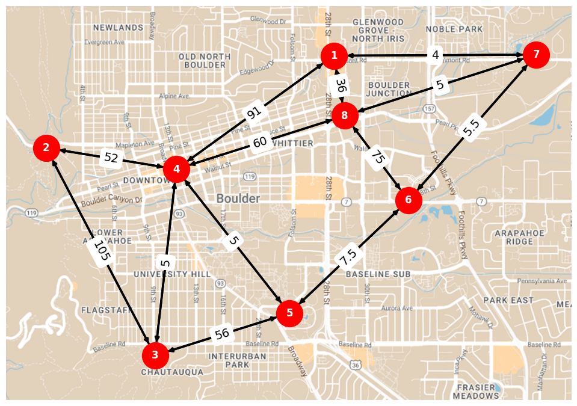

```python
# Reset all the nodes back to initial states
for node in node_list:
    node.reset_node()

# Define the starting node, set travel time to 0 (already here), the end node, and if is rush hour
start_node          = node_01
start_node.set_time(0)
end_node            = node_03
is_rush_hour        = False
include_uncertainty = True

# Find the minimum travel time and path
min_time, path = find_min_travel_time(start_node, end_node, is_rush_hour, include_uncertainty, node_list)

# Print the results
print(f'The minimum travel time from {start_node.get_name_with_id()} to {end_node.get_name_with_id()} is {min_time} minutes, following the route {path}.')

# Print the final graph data as a table
print_table(start_node, node_list)

# Visualize the graph
visualize_graph(node_list)
```

**Rush Hour + Uncertainty Results Discussion**

The code for testing our rush hour case plus uncertainty is shown below along with the corresponding results. For this scenario, our route was affected by both rush hour and uncertainty (accidents, road work, etc.). You can see both are working as intended in this scenario as the rush hour routes are scaled by a multiplier dependent on the standard normal distribution with a mean of 2 and standard deviation of .5 (see helper function above that shows this) and the uncertainty is once again a random multiplier between 10-15. Connections that are affected by the uncertainty have greater delays than those of the rush hour multiplier (because they have a higher scaling factor). Note that it is possible for a route to be affected by both rush hour and uncertainty scaling (see from 5 to 6 or 6 to 7 for examples); in those scenarios the final scaling factor is the product of rush hour and uncertainty scaling factors. In this scenario, our optimal route changed again from the base case and the optimal route found by the algorithm is 1,8,4,3 with a total time of 16.6 minutes. We verified this to be true with manual calculations once again. This route changed because traffic was bad between 1 and 4, making 1 to 8 to 4 a shorter route.

```
The minimum travel time from (1)_Movement_Boulder to (3)_Chautauqua_Park is 16.6 minutes, following the route ['(1)', '(8)', '(4)', '(3)'].
```

|  | Current Node | t_min | Visited? | Optimal Path from (1) | Neighbor Node 01 | t_base_01 | t_mod_01 | Neighbor Node 02 | t_base_02 | t_mod_02 | Neighbor Node 03 | t_base_03 | t_mod_03 | Neighbor Node 04 | t_base_04 | t_mod_04 | Neighbor Node 05 | t_base_05 | t_mod_05 |
| --- | --- | --- | --- | --- | --- | --- | --- | --- | --- | --- | --- | --- | --- | --- | --- | --- | --- | --- | --- |
| 0 | (1)_Movement_Boulder | 0.0 | Yes | [None] | (4)_Pearl_Street_Mall | 7.0 | 17.7 | (8)_Whole_Foods_Market | 3 | 6.4 | (7)_Valmont_Dog_Park | 4 | 7.6 | - | - | - | - | - | - |
| 1 | (2)_Mount_Sanitas_Trailhead | 19.3 | Yes | [(1), (8), (4), (2)] | (3)_Chautauqua_Park | 7.0 | 18.0 | (4)_Pearl_Street_Mall | 4 | 6.5 | - | - | - | - | - | - | - | - | - |
| 2 | (3)_Chautauqua_Park | 16.6 | Yes | [(1), (8), (4), (3)] | (2)_Mount_Sanitas_Trailhead | 7.0 | 18.0 | (4)_Pearl_Street_Mall | 5 | 3.8 | (5)_Fiske_Planetarium | 4 | 8.1 | - | - | - | - | - | - |
| 3 | (4)_Pearl_Street_Mall | 12.8 | Yes | [(1), (8), (4)] | (1)_Movement_Boulder | 7.0 | 17.7 | (2)_Mount_Sanitas_Trailhead | 4 | 6.5 | (3)_Chautauqua_Park | 5 | 3.8 | (5)_Fiske_Planetarium | 5 | 10.1 | (8)_Whole_Foods_Market | 5 | 6.4 |
| 4 | (5)_Fiske_Planetarium | 22.9 | Yes | [(1), (8), (4), (5)] | (3)_Chautauqua_Park | 4.0 | 8.1 | (4)_Pearl_Street_Mall | 5 | 10.1 | (6)_Peleton_West | 7.5 | 177.0 | - | - | - | - | - | - |
| 5 | (6)_Peleton_West | 15.5 | Yes | [(1), (8), (6)] | (5)_Fiske_Planetarium | 7.5 | 177.0 | (8)_Whole_Foods_Market | 5 | 9.1 | (7)_Valmont_Dog_Park | 5.5 | 177.8 | - | - | - | - | - | - |
| 6 | (7)_Valmont_Dog_Park | 7.6 | Yes | [(1), (7)] | (1)_Movement_Boulder | 4.0 | 7.6 | (8)_Whole_Foods_Market | 5 | 7.2 | (6)_Peleton_West | 5.5 | 177.8 | - | - | - | - | - | - |
| 7 | (8)_Whole_Foods_Market | 6.4 | Yes | [(1), (8)] | (1)_Movement_Boulder | 3.0 | 6.4 | (4)_Pearl_Street_Mall | 5 | 6.4 | (6)_Peleton_West | 5 | 9.1 | (7)_Valmont_Dog_Park | 5 | 7.2 | - | - | - |

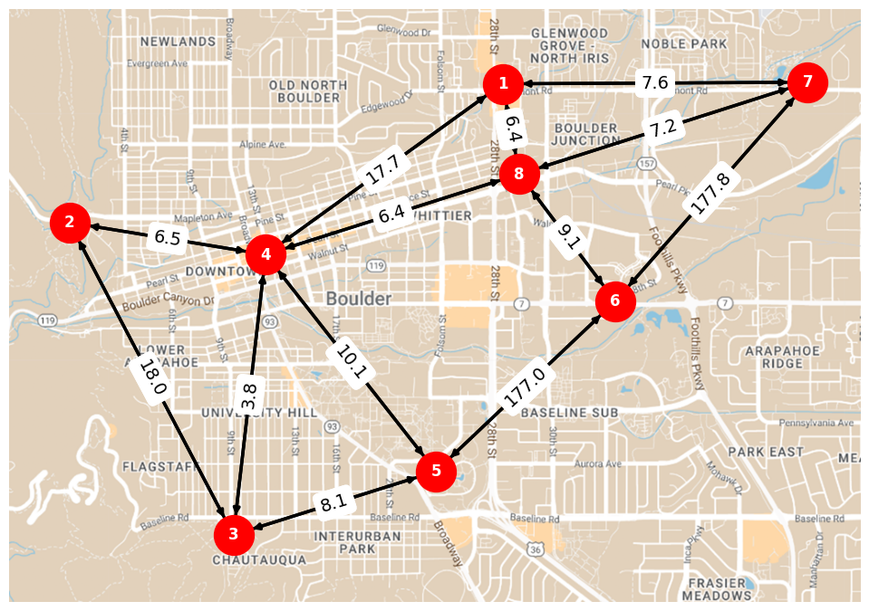

```python
# Reset all the nodes back to initial states
for node in node_list:
    node.reset_node()

# Define the starting node, set travel time to 0 (already here), the end node, and if is rush hour
start_node          = node_01
start_node.set_time(0)
end_node            = node_03
is_rush_hour        = True
include_uncertainty = True

# Find the minimum travel time and path
min_time, path = find_min_travel_time(start_node, end_node, is_rush_hour, include_uncertainty, node_list)

# Print the results
print(f'The minimum travel time from {start_node.get_name_with_id()} to {end_node.get_name_with_id()} is {min_time} minutes, following the route {path}.')

# Print the final graph data as a table
print_table(start_node, node_list)

# Visualize the graph
visualize_graph(node_list)
```